# Machine Learning Algorithm

MSK

Saturday, November 21, 2015

The goal is to use data from accelerometers on the belt, forearm, arm, and dumbell of 6 participants. They were asked to perform barbell lifts correctly and incorrectly in 5 different ways.

The data for this project come from this source: http://groupware.les.inf.puc-rio.br/har.

# Preprocessing

Data is obtained from csv files.

Training data contains entries with NA and NaNs. To deal with this problem, and removing NAs from data set, simple solution was used. Firstly,first 7 columns were removed from data set due to obsolence of this data:

```r
training <- data[,8:160]
testing <- testing[,8:160]
names(testing) <- names(training)
```

Then, the data columns with missing values vere remowed from both training and testing data sets:

```r
a <- length(na.omit(training[,1]))
for (i in 2:ncol(training)) {
  a <- rbind(a,length(na.omit(training[,i])))
}
testing <- testing[,a != 0]
training <- training[,a != 0]
a <- length(na.omit(testing[,1]))
for (i in 2:ncol(testing)) {
  a <- rbind(a,length(na.omit(testing[,i])))
}
testing <- testing[,a != 0]
training <- training[,a != 0]
```

Finally, all rows with missing values were removed:

```r
testing <- na.omit(testing)
training <- na.omit(training)
```

Data contains values obtained from various accelerometers like x,y,z coordinates. Such values might be correlated, and such correlation might indicate that few additional variables can be removed from data set. In this case Near Zero Variance is checked:

```r
nzv <- nearZeroVar(training,saveMetrics = TRUE)
nzv
```

```
##                      freqRatio percentUnique zeroVar   nzv
## roll_belt             1.101904     6.7781062   FALSE FALSE
## pitch_belt            1.036082     9.3772296   FALSE FALSE
## yaw_belt              1.058480     9.9734991   FALSE FALSE
## total_accel_belt      1.063160     0.1477933   FALSE FALSE
## gyros_belt_x          1.058651     0.7134849   FALSE FALSE
## gyros_belt_y          1.144000     0.3516461   FALSE FALSE
## gyros_belt_z          1.066214     0.8612782   FALSE FALSE
## accel_belt_x          1.055412     0.8357966   FALSE FALSE
## accel_belt_y          1.113725     0.7287738   FALSE FALSE
## accel_belt_z          1.078767     1.5237998   FALSE FALSE
## magnet_belt_x         1.090141     1.6664968   FALSE FALSE
## magnet_belt_y         1.099688     1.5187035   FALSE FALSE
## magnet_belt_z         1.006369     2.3290184   FALSE FALSE
## roll_arm             52.338462    13.5256345   FALSE FALSE
## pitch_arm            87.256410    15.7323412   FALSE FALSE
## yaw_arm              33.029126    14.6570176   FALSE FALSE
## total_accel_arm       1.024526     0.3363572   FALSE FALSE
## gyros_arm_x           1.015504     3.2769341   FALSE FALSE
## gyros_arm_y           1.454369     1.9162165   FALSE FALSE
## gyros_arm_z           1.110687     1.2638875   FALSE FALSE
## accel_arm_x           1.017341     3.9598410   FALSE FALSE
## accel_arm_y           1.140187     2.7367241   FALSE FALSE
## accel_arm_z           1.128000     4.0362858   FALSE FALSE
## magnet_arm_x          1.000000     6.8239731   FALSE FALSE
## magnet_arm_y          1.056818     4.4439914   FALSE FALSE
## magnet_arm_z          1.036364     6.4468454   FALSE FALSE
## roll_dumbbell         1.022388    84.2065029   FALSE FALSE
## pitch_dumbbell        2.277372    81.7449801   FALSE FALSE
## yaw_dumbbell          1.132231    83.4828254   FALSE FALSE
## total_accel_dumbbell  1.072634     0.2191418   FALSE FALSE
## gyros_dumbbell_x      1.003268     1.2282132   FALSE FALSE
## gyros_dumbbell_y      1.264957     1.4167771   FALSE FALSE
## gyros_dumbbell_z      1.060100     1.0498420   FALSE FALSE
## accel_dumbbell_x      1.018018     2.1659362   FALSE FALSE
## accel_dumbbell_y      1.053061     2.3748853   FALSE FALSE
## accel_dumbbell_z      1.133333     2.0894914   FALSE FALSE
## magnet_dumbbell_x     1.098266     5.7486495   FALSE FALSE
## magnet_dumbbell_y     1.197740     4.3012945   FALSE FALSE
## magnet_dumbbell_z     1.020833     3.4451126   FALSE FALSE
## roll_forearm         11.589286    11.0895933   FALSE FALSE
## pitch_forearm        65.983051    14.8557741   FALSE FALSE
## yaw_forearm          15.322835    10.1467740   FALSE FALSE
## total_accel_forearm   1.128928     0.3567424   FALSE FALSE
## gyros_forearm_x       1.059273     1.5187035   FALSE FALSE
## gyros_forearm_y       1.036554     3.7763735   FALSE FALSE
## gyros_forearm_z       1.122917     1.5645704   FALSE FALSE
## accel_forearm_x       1.126437     4.0464784   FALSE FALSE
## accel_forearm_y       1.059406     5.1116094   FALSE FALSE
## accel_forearm_z       1.006250     2.9558659   FALSE FALSE
## magnet_forearm_x      1.012346     7.7667924   FALSE FALSE
## magnet_forearm_y      1.246914     9.5403119   FALSE FALSE
## magnet_forearm_z      1.000000     8.5771073   FALSE FALSE
## classe                1.469581     0.0254816   FALSE FALSE
```

All variables with near zero variance are removed from training and testing data set:

```r
training <- training[,nzv$nzv==FALSE]
testing <- testing[,nzv$nzv==FALSE]
```

```r
remove(nzv,a,i,data)
```

# Machine learning

Since training and testing data set is prepared, machine learning subroutine can be implemented.

In this case, Random Forest method will be used with 6 fold cross validation technique:

```r
ctrl <- trainControl(method="cv", number=6)
```

To fit the model, number of 50 random trees was assigned. Such approach saves computational power and time and is enough accurte. Additioanl implemented parameter was “mtry” which is a number of variables used for prediction. In this case it is 5:

```r
modFit <- train(classe~., method="rf", ntree=50, data=training,
                do.trace=50, trControl=ctrl,
                tuneGrid = data.frame(mtry = 5))
```

```
## ntree      OOB      1      2      3      4      5
##    50:   0.70%  0.09%  1.07%  0.91%  1.49%  0.37%
## ntree      OOB      1      2      3      4      5
##    50:   0.69%  0.15%  1.01%  1.05%  1.31%  0.30%
## ntree      OOB      1      2      3      4      5
##    50:   0.65%  0.02%  0.92%  1.02%  1.38%  0.33%
## ntree      OOB      1      2      3      4      5
##    50:   0.68%  0.11%  0.76%  0.91%  1.60%  0.43%
## ntree      OOB      1      2      3      4      5
##    50:   0.67%  0.11%  0.85%  1.12%  1.38%  0.27%
## ntree      OOB      1      2      3      4      5
##    50:   0.73%  0.15%  1.14%  0.95%  1.49%  0.30%
## ntree      OOB      1      2      3      4      5
##    50:   0.48%  0.11%  0.47%  0.82%  1.03%  0.28%
```

```r
modFit
```

```
## Random Forest
##
## 19622 samples
##    52 predictor
##     5 classes: 'A', 'B', 'C', 'D', 'E'
##
## No pre-processing
## Resampling: Cross-Validated (6 fold)
## Summary of sample sizes: 16350, 16352, 16351, 16352, 16352, 16353, ...
## Resampling results
##
##   Accuracy   Kappa      Accuracy SD  Kappa SD
##   0.9948525  0.9934889  0.00124549   0.001575394
##
## Tuning parameter 'mtry' was held constant at a value of 5
##
```

Prediction:

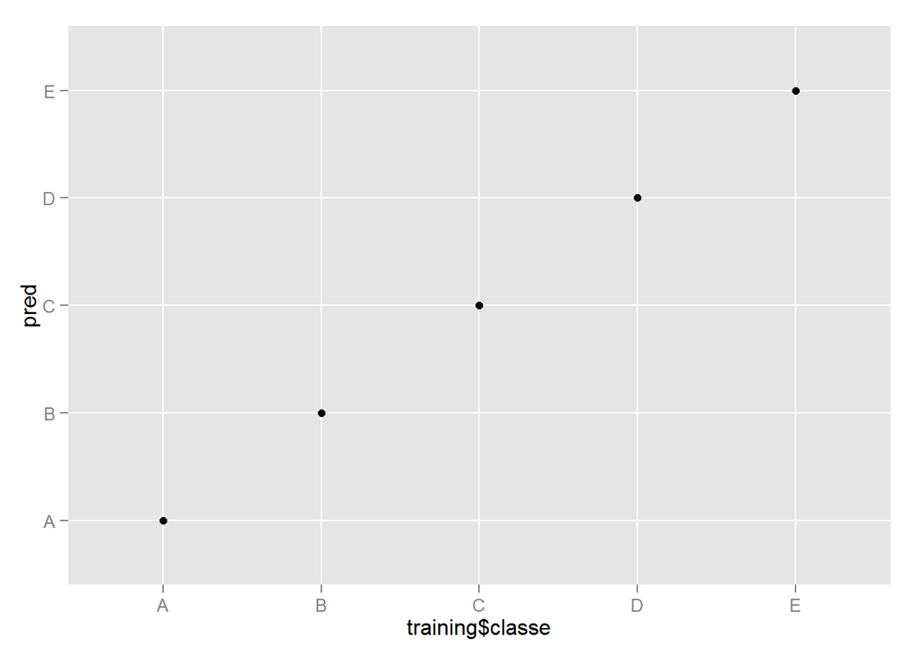

```r
pred <- predict(modFit,training)
qplot(training$classe,pred,data=training)
```

# Accuracy of model

Confusion matrix will simply show how accuretely the model is based on training data:

```r
confusionMatrix(training$classe,pred)
```

```
## Confusion Matrix and Statistics
##
##           Reference
## Prediction    A    B    C    D    E
##          A 5580    0    0    0    0
##          B    0 3797    0    0    0
##          C    0    0 3422    0    0
##          D    0    0    0 3216    0
##          E    0    0    0    0 3607
##
## Overall Statistics
##
##                Accuracy : 1
##                  95% CI : (0.9998, 1)
##     No Information Rate : 0.2844
##     P-Value [Acc > NIR] : < 2.2e-16
##
##                   Kappa : 1
##  Mcnemar's Test P-Value : NA
##
## Statistics by Class:
##
##                      Class: A Class: B Class: C Class: D Class: E
## Sensitivity            1.0000   1.0000   1.0000   1.0000   1.0000
## Specificity            1.0000   1.0000   1.0000   1.0000   1.0000
## Pos Pred Value         1.0000   1.0000   1.0000   1.0000   1.0000
## Neg Pred Value         1.0000   1.0000   1.0000   1.0000   1.0000
## Prevalence             0.2844   0.1935   0.1744   0.1639   0.1838
## Detection Rate         0.2844   0.1935   0.1744   0.1639   0.1838
## Detection Prevalence   0.2844   0.1935   0.1744   0.1639   0.1838
## Balanced Accuracy      1.0000   1.0000   1.0000   1.0000   1.0000
```

# Prediction

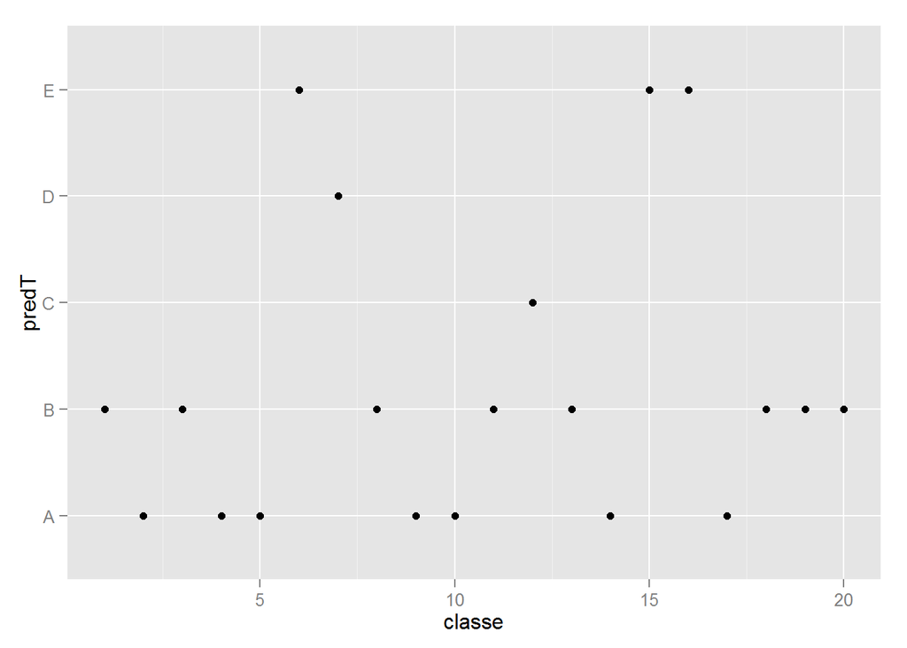

```r
predT <- predict(modFit,testing)
qplot(classe,predT,data=testing)
```

```r
summary(predT)
```

```
## A B C D E
## 7 8 1 1 3
```